# Classification of data from a particular news collection into categories such as international news and travel using machine learning and deep learning. Short description of the news dataset is used f

# 12)Merging the Train and valid dataset into one dataset and performing preprocessing

```python
a_X = pd.concat([X_train, X_valid], axis=0)
```

```python
a_X
```

|  | headline | authors | link | short_description | date | c_id |
| --- | --- | --- | --- | --- | --- | --- |
| 2989 | how can you miss america's national parks if t... | christopher elliott, contributor\nauthor, how ... | https://www.huffingtonpost.com/entry/how-can-y... | how can you miss america's national parks if t... | 2013-10-21 | 1 |
| 5433 | eating at the world's best restaurant: el cell... | scott adams, contributor\nadventure travel and... | https://www.huffingtonpost.com/entry/eating-at... | eating at the world's best restaurant: el cell... | 2014-04-10 | 1 |
| 6328 | will the palestinians ever play their cards ri... | alon ben-meir, contributorsenior fellow, cente... | https://www.huffingtonpost.com/entry/will-the-... | will the palestinians ever play their cards ri... | 2017-10-12 | 0 |
| 2280 | ciao, bella! where to find italy's sexy nightlife | party earth, contributor\ncontributor | https://www.huffingtonpost.com/entry/ciao-bell... | ciao, bella! where to find italy's sexy nightl... | 2013-07-26 | 1 |
| 4578 | world's only flying eye hospital provides eye ... | madeline diamond | https://www.huffingtonpost.com/entry/flying-ey... | world's only flying eye hospital provides eye ... | 2016-07-08 | 1 |
| ... | ... | ... | ... | ... | ... | ... |
| 2760 | lipstick under my burkha: when real women take... | the conversation global, contributorthe conver... | https://www.huffingtonpost.com/entry/lipstick-... | lipstick under my burkha: when real women take... | 2017-06-01 | 0 |
| 6246 | best places to glamp | u.s. news travel, contributor\nu.s. news & wor... | https://www.huffingtonpost.com/entry/best-plac... | best places to glampare you fond of the great ... | 2013-06-18 | 1 |
| 1161 | insider tips on austin for sxsw attendees (pho... | fortnighter, contributor\nwww.fortnighter.com | https://www.huffingtonpost.com/entry/insider-t... | insider tips on austin for sxsw attendees (pho... | 2012-03-13 | 1 |
| 2270 | different from the norm: 12 unique hotel stays... | oyster, contributorvisiting, photographing, re... | https://www.huffingtonpost.com/entry/different... | different from the norm: 12 unique hotel stays... | 2014-09-09 | 1 |
| 4382 | refugee or migrant? sometimes the line is blurred | the conversation global, contributorthe conver... | https://www.huffingtonpost.com/entry/refugee-o... | refugee or migrant? sometimes the line is blur... | 2017-06-20 | 0 |

4821 rows × 6 columns

```python
a_Y = pd.concat([y_train, y_valid], axis=0)
```

```python
a_Y
```

```
2989    1
5433    1
6328    0
2280    1
4578    1
       ..
2760    0
6246    1
1161    1
2270    1
4382    0
Name: category, Length: 4821, dtype: int64
```

Preprocessing the merged dataset by removing stopwords, lemmatizing and removing other columns rather than short description

```python
def remove_stopwords(text):
  stop_words = set(stopwords.words('english'))
  words = word_tokenize(text)
  return " ".join([x for x in words if x not in stop_words])
a_X['short_description'] = a_X['short_description'].apply(remove_stopwords)
a_X
```

|  | headline | authors | link | short_description | date | c_id |
| --- | --- | --- | --- | --- | --- | --- |
| 2989 | how can you miss america's national parks if t... | christopher elliott, contributor\nauthor, how ... | https://www.huffingtonpost.com/entry/how-can-y... | miss america 's national parks never go away ?... | 2013-10-21 | 1 |
| 5433 | eating at the world's best restaurant: el cell... | scott adams, contributor\nadventure travel and... | https://www.huffingtonpost.com/entry/eating-at... | eating world 's best restaurant : el celler de... | 2014-04-10 | 1 |
| 6328 | will the palestinians ever play their cards ri... | alon ben-meir, contributorsenior fellow, cente... | https://www.huffingtonpost.com/entry/will-the-... | palestinians ever play cards right ? current e... | 2017-10-12 | 0 |
| 2280 | ciao, bella! where to find italy's sexy nightlife | party earth, contributor\ncontributor | https://www.huffingtonpost.com/entry/ciao-bell... | ciao , bella ! find italy 's sexy nightlifemoy... | 2013-07-26 | 1 |
| 4578 | world's only flying eye hospital provides eye ... | madeline diamond | https://www.huffingtonpost.com/entry/flying-ey... | world 's flying eye hospital provides eye care... | 2016-07-08 | 1 |
| ... | ... | ... | ... | ... | ... | ... |
| 2760 | lipstick under my burkha: when real women take... | the conversation global, contributorthe conver... | https://www.huffingtonpost.com/entry/lipstick-... | lipstick burkha : real women take indian scree... | 2017-06-01 | 0 |
| 6246 | best places to glamp | u.s. news travel, contributor\nu.s. news & wor... | https://www.huffingtonpost.com/entry/best-plac... | best places glampare fond great outdoors ... m... | 2013-06-18 | 1 |
| 1161 | insider tips on austin for sxsw attendees (pho... | fortnighter, contributor\nwww.fortnighter.com | https://www.huffingtonpost.com/entry/insider-t... | insider tips austin sxsw attendees ( photos ) ... | 2012-03-13 | 1 |
| 2270 | different from the norm: 12 unique hotel stays... | oyster, contributorvisiting, photographing, re... | https://www.huffingtonpost.com/entry/different... | different norm : 12 unique hotel stays nycforg... | 2014-09-09 | 1 |
| 4382 | refugee or migrant? sometimes the line is blurred | the conversation global, contributorthe conver... | https://www.huffingtonpost.com/entry/refugee-o... | refugee migrant ? sometimes line blurredfrom l... | 2017-06-20 | 0 |

4821 rows × 6 columns

```python
w_tokenizer = nltk.tokenize.WhitespaceTokenizer()
lemmatizer = nltk.stem.WordNetLemmatizer()

def lemmatize_text(text):
    return " ".join([lemmatizer.lemmatize(w) for w in w_tokenizer.tokenize(text)])


a_X['short_description'] = a_X.short_description.apply(lemmatize_text)
```

```python
del a_X['authors']
del a_X['link']
del a_X['headline']
del a_X['date']
```

```python
del a_X['c_id']
```

```python
a_X
```

|  | short_description |
| --- | --- |
| 2989 | miss america 's national park never go away ? ... |
| 5433 | eating world 's best restaurant : el celler de... |
| 6328 | palestinian ever play card right ? current eff... |
| 2280 | ciao , bella ! find italy 's sexy nightlifemoy... |
| 4578 | world 's flying eye hospital provides eye care... |
| ... | ... |
| 2760 | lipstick burkha : real woman take indian scree... |
| 6246 | best place glampare fond great outdoors ... mi... |
| 1161 | insider tip austin sxsw attendee ( photo ) fri... |
| 2270 | different norm : 12 unique hotel stay nycforge... |
| 4382 | refugee migrant ? sometimes line blurredfrom l... |

4821 rows × 1 columns

```python
def special_char(text):
  reviews = ''
  for x in text:
    if x.isalnum():
      reviews = reviews + x
    else:
      reviews = reviews + ' '
  return reviews
a_X['short_description'] = a_X['short_description'].apply(special_char)
a_X
```

|  | short_description |
| --- | --- |
| 2989 | miss america s national park never go away ... |
| 5433 | eating world s best restaurant el celler de... |
| 6328 | palestinian ever play card right current eff... |
| 2280 | ciao bella find italy s sexy nightlifemoy... |
| 4578 | world s flying eye hospital provides eye care... |
| ... | ... |
| 2760 | lipstick burkha real woman take indian scree... |
| 6246 | best place glampare fond great outdoors mi... |
| 1161 | insider tip austin sxsw attendee photo fri... |
| 2270 | different norm 12 unique hotel stay nycforge... |
| 4382 | refugee migrant sometimes line blurredfrom l... |

4821 rows × 1 columns

Vectorizing the short description of merged train and valid dataset using term frequency vectorizer

```python
tfidf_vectt_merged = TfidfVectorizer(analyzer='word', max_features=6000)

x_tfidfft_merged = tfidf_vectt_merged.fit_transform(a_X['short_description'])

x_featuress_tmerged= pd.DataFrame(x_tfidfft_merged .toarray())
```

Initialising our KFold object with 5 splits to run K-fold Cross Validation on merged train and valid dataset

```python
folder = KFold(n_splits=5)
```

```python
results = cross_val_score(dt_modelv , x_featuress_tmerged, a_Y, cv = folder)# Parameters are, in order - model, X data, labels (y), and the KFold object
results
```

```
array([0.89222798, 0.88381743, 0.87344398, 0.86721992, 0.87863071])
```

```python
output = df(results, columns=["Accuracy_per_fold"])
output
```

|  | Accuracy_per_fold |
| --- | --- |
| 0 | 0.892228 |
| 1 | 0.883817 |
| 2 | 0.873444 |
| 3 | 0.867220 |
| 4 | 0.878631 |

Accuracy of K-Fold Cross Validation using Decision Tree Classifier

```python
# the mean of the column!
av_val = output["Accuracy_per_fold"].mean()*100
print("The average accuracy across folds is {}%".format(av_val))
```

```
The average accuracy across folds is 87.90680024939263%
```

Initialising our KFold object with 5 splits to run K-fold Cross Validation on merged train and valid dataset

```python
results1 = cross_val_score(rfc_modelv , x_featuress_tmerged, a_Y, cv = folder)# Parameters are, in order - model, X data, labels (y), and the KFold object
results1
```

```
array([0.91398964, 0.90560166, 0.91804979, 0.92219917, 0.93049793])
```

```python
output1 = df(results1, columns=["Accuracy_per_fold"])
output1
```

|  | Accuracy_per_fold |
| --- | --- |
| 0 | 0.913990 |
| 1 | 0.905602 |
| 2 | 0.918050 |
| 3 | 0.922199 |
| 4 | 0.930498 |

Accuracy of K-Fold Cross Validation using Random Forest Classifier

```python
#get the mean of the column!
av_val = output1["Accuracy_per_fold"].mean()*100
print("The average accuracy across folds is {}%".format(av_val))
```

```
The average accuracy across folds is 91.80676370047085%
```

## 13. Choosing the random forest classifier to run on test dataset after doing modification in the train dataset which has the best accuracy scores from 11)

Loading the test dataset

```python
testtt=pd.read_csv('test.csv')
```

```python
testtt
```

|  | headline | authors | link | short_description | date | c_id |
| --- | --- | --- | --- | --- | --- | --- |
| 0 | suicide bomber kills dozens outside voter regi... | qadir sediqi and sayed hassib, reuters | https://www.huffingtonpost.com/entry/suicide-b... | suicide bomber kills dozens outside voter regi... | 2018-04-22 | 0 |
| 1 | football, food and fun in nashville | rob taub, contributor\nwriter & television/rad... | https://www.huffingtonpost.com/entry/football-... | football, food and fun in nashville"i always c... | 2012-12-20 | 1 |
| 2 | coolest hotel amenities in the hamptons | oyster.com, contributor\nthe hotel tell-all | https://www.huffingtonpost.com/entry/coolest-h... | coolest hotel amenities in the hamptonstake a ... | 2013-05-03 | 1 |
| 3 | paris in china: tianducheng is an eerie, aband... | lisa_miller | https://www.huffingtonpost.com/entry/paris-chi... | paris in china: tianducheng is an eerie, aband... | 2013-08-07 | 1 |
| 4 | so what is this "st.patrick's day" nonsense al... | quora, contributor\nthe best answer to any que... | https://www.huffingtonpost.com/entry/so-what-i... | so what is this "st.patrick's day" nonsense al... | 2013-03-15 | 1 |
| ... | ... | ... | ... | ... | ... | ... |
| 1602 | 5 ski resort beer festivals not to miss | liftopia, contributorski deals online - www.li... | https://www.huffingtonpost.com/entry/5-ski-res... | 5 ski resort beer festivals not to missski res... | 2014-08-13 | 1 |
| 1603 | here's why you've never heard of the titanic's... | kimberly yam | https://www.huffingtonpost.com/entry/titanic-c... | here's why you've never heard of the titanic's... | 2018-04-18 | 0 |
| 1604 | new york city birthday adventure: toy soldier ... | lisa a. tucker, contributor\nlaw professor, tr... | https://www.huffingtonpost.com/entry/new-york-... | new york city birthday adventure: toy soldier ... | 2012-03-12 | 1 |
| 1605 | breezes bahamas offers discount to hurricane n... | lisa_miller | https://www.huffingtonpost.com/entry/breezes-b... | breezes bahamas offers discount to hurricane n... | 2013-08-21 | 1 |
| 1606 | news roundup for august 21, 2017 | outspeak, contributoroutspeakâ¢ is the opinio... | https://www.huffingtonpost.com/entry/news-roun... | news roundup for august 21, 2017in honor of th... | 2017-08-21 | 0 |

1607 rows × 6 columns

Removing all the column rather than short description and category in Test dataset

```python
del testtt['authors']
del testtt['link']
del testtt['headline']
del testtt['date']
```

Preprocessing techniques like removing tags,special characters,stop words and lemmatizing the test dataset

```python
def remove_tags(text):
  remove = re.compile(r'')
  return re.sub(remove, '', text)
testtt['short_description'] = testtt['short_description'].apply(remove_tags)

def special_char(text):
  reviews = ''
  for x in text:
    if x.isalnum():
      reviews = reviews + x
    else:
      reviews = reviews + ' '
  return reviews
testtt['short_description'] = testtt['short_description'].apply(special_char)

def remove_stopwords(text):
  stop_words = set(stopwords.words('english'))
  words = word_tokenize(text)
  return " ".join([x for x in words if x not in stop_words])
testtt['short_description'] = testtt['short_description'].apply(remove_stopwords)

w_tokenizer = nltk.tokenize.WhitespaceTokenizer()
lemmatizer = nltk.stem.WordNetLemmatizer()

def lemmatize_text(text):
    return " ".join([lemmatizer.lemmatize(w) for w in w_tokenizer.tokenize(text)])


testtt['short_description'] = testtt.short_description.apply(lemmatize_text)
testtt
```

|  | short_description | c_id |
| --- | --- | --- |
| 0 | suicide bomber kill dozen outside voter regist... | 0 |
| 1 | football food fun nashville always combine foo... | 1 |
| 2 | coolest hotel amenity hamptonstake look hotel ... | 1 |
| 3 | paris china tianducheng eerie abandoned city l... | 1 |
| 4 | st patrick day nonsense anyway 2 saint couple ... | 1 |
| ... | ... | ... |
| 1602 | 5 ski resort beer festival missski resort offe... | 1 |
| 1603 | never heard titanic chinese survivorsa century... | 0 |
| 1604 | new york city birthday adventure toy soldier a... | 1 |
| 1605 | breeze bahamas offer discount hurricane name g... | 1 |
| 1606 | news roundup august 21 2017in honor shitshow 2... | 0 |

1607 rows × 2 columns

Vectorizing using Term frequency vectorizer on test dataset for short description

```python
tfidf_test= TfidfVectorizer(analyzer='word', max_features=6000)

x_tfidftest= tfidf_test.fit_transform(testtt['short_description'])

x_featuresxtest = pd.DataFrame(x_tfidftest.toarray())
```

Splitiing the test dataset into train and test to use classifiers

```python
x_traintest, x_testtest, y_traintest, y_testtest = train_test_split(x_featuresxtest, testtt['c_id'], test_size=.2)
```

```python
rfcmerged_model = RandomForestClassifier().fit(x_traintest, y_traintest)
mymodel = open('rtctrainmod.sav', 'wb')
pickle.dump( rfcmerged_model, mymodel)
mymodel.close()
rfcpredav = rfcmerged_model.predict(x_testtest)
```

```python
filename = 'rtctrainmod.sav'
saved_clf = pickle.load(open(filename, 'rb'))
saved_clf.score(x_testtest, y_testtest)
```

```
0.9037267080745341
```

Accuracy classification report with error analysis

```python
print("---Test Set Results---")
print("Accuracy with logreg: {}".format(accuracy_score(y_testtest, rfcpredav)))
print(classification_report(y_testtest, rfcpredav))
```

```
---Test Set Results---
Accuracy with logreg: 0.9037267080745341
              precision    recall  f1-score   support

           0       0.96      0.63      0.76        79
           1       0.89      0.99      0.94       243

    accuracy                           0.90       322
   macro avg       0.93      0.81      0.85       322
weighted avg       0.91      0.90      0.90       322
```

Splitiing themerged dataset train and valid merged dataset to run classifiers

```python
x_train_mergedd, x_test_merged, y_train_merged, y_test_merged = train_test_split(x_featuress_tmerged, a_Y, test_size=0.5)
```

## Running random forest classifier on merged dataset as it gave the best accuracy score on cross validation of merged dataset

```python
# rfcmergedd = RandomForestClassifier()

# rfcmerged_model = rfcmergedd.fit(x_train_mergedd, y_train_merged)

# rfcmergepred = rfcmerged_model.predict(x_test_merged)

# print('Accuracy score :- {}'.format(round(accuracy_score(y_test_merged, rfcmergepred), 2)))
# print("Train data accuracy:",accuracy_score(y_train_merged,rfcmergepred))

# print(format(classification_report(y_test_merged, rfcmergepred,zero_division=1)))
rfcmerged_model = RandomForestClassifier().fit(x_train_mergedd, y_train_merged)
mymodel = open('rtctrainmod.sav', 'wb')
pickle.dump( rfcmerged_model, mymodel)
mymodel.close()
rfcpredav = rfcmerged_model.predict(x_test_merged)
```

```python
filename = 'rtctrainmod.sav'
saved_clf = pickle.load(open(filename, 'rb'))
saved_clf.score(x_test_merged, y_test_merged)
```

```
0.9112401493156367
```

```python
print("---Test Set Results---")
print("Accuracy with logreg: {}".format(accuracy_score(y_test_merged, rfcpredav)))
print(classification_report(y_test_merged, rfcpredav))
```

```
---Test Set Results---
Accuracy with logreg: 0.9112401493156367
              precision    recall  f1-score   support

           0       0.93      0.71      0.80       622
           1       0.91      0.98      0.94      1789

    accuracy                           0.91      2411
   macro avg       0.92      0.85      0.87      2411
weighted avg       0.91      0.91      0.91      2411
```

Using the saved random forest classifier model of merged dataset on test dataset

```python
filename = 'rtctrainmod.sav'
saved_clfa = pickle.load(open(filename, 'rb'))
saved_clfa.score(x_testtest, y_testtest)
```

```
0.7515527950310559
```

```python
y_predictionmodela = rfcmerged_model.predict(x_testtest)
print("---Test Set Results---")
print("Accuracy with logreg: {}".format(accuracy_score(y_testtest, y_predictionmodela)))
print(classification_report(y_testtest, y_predictionmodela))
```

```
---Test Set Results---
Accuracy with logreg: 0.7515527950310559
              precision    recall  f1-score   support

           0       0.47      0.09      0.15        79
           1       0.77      0.97      0.85       243

    accuracy                           0.75       322
   macro avg       0.62      0.53      0.50       322
weighted avg       0.69      0.75      0.68       322
```

## 7)Deep Learning from the scratch-- Taking the copy of whole dataset

```python
copya = pd.DataFrame(mydata)

#Make a copy:

hypertuning = copya.copy()

print(hypertuning)
```

```
        id  category                                           headline  \
0        0         0  south korea working to formally end the korean...
1        1         1   savor the south at one of these summer festivals
3        3         1  panama city is central america's past and futu...
4        4         1       things to do in the land of the royal family
5        5         0  huge fire erupts at tomorrowland festival in s...
...    ...       ...                                                ...
7995  7995         1  world's most dangerous path undergoing safety ...
7996  7996         1  epic pictures of bolivia's salt flats prove it...
7997  7997         1       zihuatenejo: still mexico's best kept secret
7998  7998         0              india test-fires nuclear-capable icbm
7999  7999         0  theresa may secures deal with northern ireland...

                                                authors  \
0                                           nick visser
```

[output cut: 38 more lines]

Reducing the length of rows to 1000 to hypertune and regualrize the small dataset

```python
hypertuning=hypertuning[0:1000]
len(hypertuning)
```

```
1000
```

Merging the headline and short description into sentence

```python
hypertuning["sentence"]=hypertuning['headline']+hypertuning['short_description']
hypertuning["category"]=hypertuning['category']
```

removing all other columns rather than sentence and category

```python
del hypertuning['authors']
del hypertuning['link']
del hypertuning['headline']
del hypertuning['date']
del hypertuning['id']
del hypertuning['short_description']
del hypertuning['c_id']

hypertuning
```

|  | category | sentence |
| --- | --- | --- |
| 0 | 0 | south korea working to formally end the korean... |
| 1 | 1 | savor the south at one of these summer festiva... |
| 3 | 1 | panama city is central america's past and futu... |
| 4 | 1 | things to do in the land of the royal familyth... |
| 5 | 0 | huge fire erupts at tomorrowland festival in s... |
| ... | ... | ... |
| 1267 | 0 | as rohingyas flee myanmar, india needs to drop... |
| 1268 | 0 | united states' image takes a beating under tru... |
| 1269 | 1 | my roman holidaymy roman holidayhistory travel... |
| 1272 | 1 | london dining: steak near covent garden and le... |
| 1273 | 1 | 9 carbon copies of world-famous landmarks9 car... |

1000 rows × 2 columns

building vocabulary from dataset

```python
time_steps = 100


def build_vocabulary(sentence_list):
    unique_words = " ".join(sentence_list).strip().split()
    word_count = Counter(unique_words).most_common()
    vocabulary = {}
    for word, _ in word_count:
        vocabulary[word] = len(vocabulary)

    return vocabulary

vocabulary = build_vocabulary(hypertuning["sentence"])
```

```python
inputs = Input(shape=(500, ))
embedding_layer = Embedding(len(vocabulary),
                            16,input_length=500)(inputs)
word_embedding= BatchNormalization()(embedding_layer)

x = LSTM(128)(word_embedding)
x = Dense(64, activation='relu')(x)
x = Dense(32, activation='relu')(x)
predictions = Dense(2, activation='softmax')(x)
model = Model(inputs=[inputs], outputs=predictions)
model.compile(optimizer='adam',
              loss='categorical_crossentropy',
              metrics=['acc'])

model.summary()
```

```
Model: "model"
_________________________________________________________________
 Layer (type)                Output Shape              Param #
=================================================================
 input_1 (InputLayer)        [(None, 500)]             0

 embedding (Embedding)       (None, 500, 16)           176208

 batch_normalization (BatchN  (None, 500, 16)          64
 ormalization)

 lstm (LSTM)                 (None, 128)               74240

 dense (Dense)               (None, 64)                8256

 dense_1 (Dense)             (None, 32)                2080

 dense_2 (Dense)             (None, 2)                 66

=================================================================
Total params: 260,914
Trainable params: 260,882
Non-trainable params: 32
_________________________________________________________________
```

Create datasets (Only take up to time_steps words for memory)

```python
train_text = hypertuning['sentence'].tolist()
train_text = [' '.join(t.split()[0:time_steps]) for t in train_text]
train_text = np.array(train_text)
train_label = np.array(hypertuning['category'].tolist())
```

Preprocessing the dataset

```python
MAX_LENGTH = 500
tokenizer = Tokenizer()
tokenizer.fit_on_texts(train_text)
post_seq = tokenizer.texts_to_sequences(train_text)
post_seq_padded = pad_sequences(post_seq, maxlen=MAX_LENGTH)
```

Splitting the dataset to hypertune

```python
X_trainhypertuning, X_testhypertuning, y_trainhypertuning, y_testhypertuning = train_test_split(post_seq_padded, train_label, test_size=0.5)
```

```python
history = model.fit([X_trainhypertuning], y=to_categorical(y_trainhypertuning), verbose=1, validation_split=0.25,
          shuffle=False, epochs=5)
```

```python
model.evaluate(X_testhypertuning,to_categorical(y_testhypertuning))
```

```
[0.8512983322143555, 0.2800000011920929]
```

### - To decrease overfitting in my simple model and for that aim I decreased my sample to 1000.

### - At the above we can see my base model there is huge overfitting like almost %30

## Adding Dropout Layer

```python
result = {}
y = {}
loss = []
acc = []
dropouts = [0.0, 0.1, 0.2, 0.3]
for dropout in dropouts:
    print ("Dropout: ", dropout)

    inputs = Input(shape=(500, ))
    embedding_layer = Embedding(len(vocabulary),
                            16,input_length=500)(inputs)
    word_embedding= BatchNormalization()(embedding_layer)

    x = LSTM(128)(word_embedding)
    x = Dense(64, activation='relu')(x)
    x = Dropout(dropout)(x)
    x = Dense(32, activation='relu')(x)
    predictions = Dense(2, activation='softmax')(x)
    model = Model(inputs=[inputs], outputs=predictions)
    model.compile(optimizer='adam',
              loss='categorical_crossentropy',
              metrics=['acc'])
    model_simple = model.fit([X_trainhypertuning], batch_size=64, y=to_categorical(y_trainhypertuning), verbose=1, validation_split=0.25,
          shuffle=False, epochs=5)
    score = model.evaluate(X_testhypertuning, to_categorical(y_testhypertuning),verbose=0)
    y[dropout] = model.predict(X_testhypertuning)
    print('Test score:', score[0])
    print('Test accuracy:', score[1])
    result[dropout] = copy.deepcopy(model_simple.history)
    loss.append(score[0])
    acc.append(score[1])
```

```
Dropout:  0.0
Test score: 0.6882838010787964
Test accuracy: 0.7200000286102295
Dropout:  0.1
Test score: 0.6920948028564453
Test accuracy: 0.5419999957084656
Dropout:  0.2
Test score: 0.6796628832817078
Test accuracy: 0.7200000286102295
Dropout:  0.3
Test score: 0.6778554320335388
Test accuracy: 0.7200000286102295
```

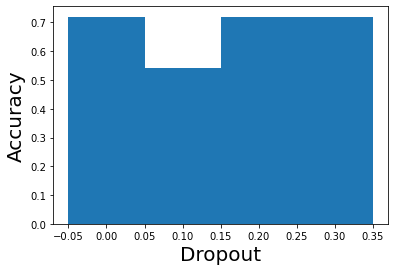

```python
width = 0.1

plt.bar(dropouts, acc, width, align='center')
#plt.figure(figsize=(50,50))
plt.tick_params(axis='both', which='major', labelsize=10)
plt.tick_params(axis='both', which='minor', labelsize=10)

plt.ylabel('Accuracy',size = 20)
plt.xlabel('Dropout', size = 20)
plt.show()
```

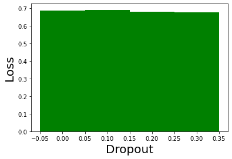

```python
width = 0.1

plt.bar(dropouts, loss, width, align='center',color = 'green')

plt.tick_params(axis='both', which='major', labelsize=10)
plt.tick_params(axis='both', which='minor', labelsize=10)

plt.ylabel('Loss',size = 20)
plt.xlabel('Dropout', size = 20)
plt.show()
```

fine tuning hyper parameters

```python
result = {}
y = {}
loss = []
acc = []

learning_rates = [0.1,0.01,0.001]
lr_weight_decay = 0.95

for lr in learning_rates:
    print ("Learning rate: ", lr)

    inputs = Input(shape=(500, ))
    embedding_layer = Embedding(len(vocabulary),
                            16,input_length=500)(inputs)
    word_embedding= BatchNormalization()(embedding_layer)

    x = LSTM(128)(word_embedding)
    x = Dense(64, activation='relu')(x)
    x = Dropout(0.1)(x)
    x = Dense(32, activation='relu')(x)
    predictions = Dense(2, activation='softmax')(x)
    model = Model(inputs=[inputs], outputs=predictions)
    adam = optimizers.Adam(lr,decay=lr_weight_decay)
    model.compile(optimizer='adam',
                  loss='categorical_crossentropy',
                  metrics=['acc'])

    model_simple = model.fit([X_trainhypertuning], batch_size=64, y=to_categorical(y_trainhypertuning), verbose=1, validation_split=0.25,
          shuffle=False, epochs=5)
    score = model.evaluate(X_testhypertuning, to_categorical(y_testhypertuning),verbose=0)
    y[lr] = model.predict(X_testhypertuning)
    print('Test score:', score[0])
    print('Test accuracy:', score[1])
    result[lr] = copy.deepcopy(model_simple.history)
    loss.append(score[0])
    acc.append(score[1])
```

```
Learning rate:  0.1
Test score: 0.6787021160125732
Test accuracy: 0.7200000286102295
Learning rate:  0.01
Test score: 0.7105197906494141
Test accuracy: 0.2800000011920929
Learning rate:  0.001
Test score: 0.7026596665382385
Test accuracy: 0.28999999165534973
```

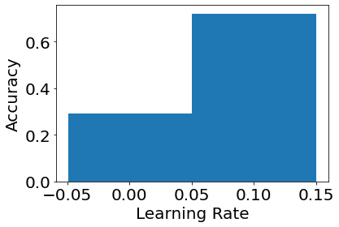

```python
width = 0.1

plt.bar(learning_rates, acc, width, align='center')
#plt.figure(figsize=(50,50))
plt.tick_params(axis='both', which='major', labelsize=20)
plt.tick_params(axis='both', which='minor', labelsize=20)

plt.ylabel('Accuracy',size = 20)
plt.xlabel('Learning Rate', size = 20)
plt.show()
```

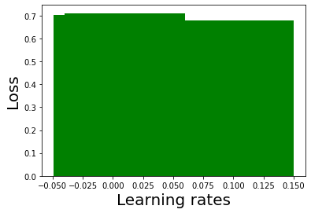

```python
width = 0.1

plt.bar(learning_rates, loss, width, align='center',color = 'green')

plt.tick_params(axis='both', which='major', labelsize=10)
plt.tick_params(axis='both', which='minor', labelsize=10)

plt.ylabel('Loss',size = 20)
plt.xlabel('Learning rates', size = 20)
plt.show()
```

## So also we can try different optimizer as RMSPROP

```python
inputs = Input(shape=(500, ))
embedding_layer = Embedding(len(vocabulary),
                            16,input_length=500)(inputs)
word_embedding= BatchNormalization()(embedding_layer)

x = LSTM(128)(word_embedding)
x = Dense(64, activation='relu')(x)
x = Dropout(0.1)(x)
x = Dense(32, activation='relu')(x)
predictions = Dense(2, activation='softmax')(x)
model = Model(inputs=[inputs], outputs=predictions)
rmsprop = optimizers.RMSprop(learning_rate=0.001, decay=0.95)
model.compile(optimizer='rmsprop',
              loss='categorical_crossentropy',
              metrics=['acc'])

model.summary()
```

```
Model: "model_8"
_________________________________________________________________
 Layer (type)                Output Shape              Param #
=================================================================
 input_9 (InputLayer)        [(None, 500)]             0

 embedding_8 (Embedding)     (None, 500, 16)           176208

 batch_normalization_8 (Batc  (None, 500, 16)          64
 hNormalization)

 lstm_8 (LSTM)               (None, 128)               74240

 dense_24 (Dense)            (None, 64)                8256

 dropout_7 (Dropout)         (None, 64)                0

 dense_25 (Dense)            (None, 32)                2080

 dense_26 (Dense)            (None, 2)                 66

=================================================================
Total params: 260,914
Trainable params: 260,882
Non-trainable params: 32
_________________________________________________________________
```

```python
model_simple = model.fit([X_trainhypertuning], batch_size=64, y=to_categorical(y_trainhypertuning), verbose=1, validation_split=0.25,
          shuffle=False, epochs=5)
```

```python
predicted=model.predict(X_testhypertuning)
predicted = np.argmax(predicted, axis=1)
print(accuracy_score(y_testhypertuning, predicted))
```

```
0.28
```

Taking a copy of the whole dataframe to optimize using rmsprop

```python
copya = pd.DataFrame(mydata)

#Make a copy:

hypertuninga = copya.copy()

print(hypertuninga)
```

```
        id  category                                           headline  \
0        0         0  south korea working to formally end the korean...
1        1         1   savor the south at one of these summer festivals
3        3         1  panama city is central america's past and futu...
4        4         1       things to do in the land of the royal family
5        5         0  huge fire erupts at tomorrowland festival in s...
...    ...       ...                                                ...
7995  7995         1  world's most dangerous path undergoing safety ...
7996  7996         1  epic pictures of bolivia's salt flats prove it...
7997  7997         1       zihuatenejo: still mexico's best kept secret
7998  7998         0              india test-fires nuclear-capable icbm
7999  7999         0  theresa may secures deal with northern ireland...

                                                authors  \
0                                           nick visser
```

[output cut: 38 more lines]

Merging the headline and short descsription to a sentence column

```python
hypertuninga["sentence"]=hypertuninga['headline']+hypertuninga['short_description']
hypertuninga["category"]=hypertuninga['category']
```

Removing all the columns rather than category and sentence

```python
del hypertuninga['authors']
del hypertuninga['link']
del hypertuninga['headline']
del hypertuninga['date']
del hypertuninga['id']
del hypertuninga['short_description']
del hypertuninga['c_id']

hypertuninga
```

|  | category | sentence |
| --- | --- | --- |
| 0 | 0 | south korea working to formally end the korean... |
| 1 | 1 | savor the south at one of these summer festiva... |
| 3 | 1 | panama city is central america's past and futu... |
| 4 | 1 | things to do in the land of the royal familyth... |
| 5 | 0 | huge fire erupts at tomorrowland festival in s... |
| ... | ... | ... |
| 7995 | 1 | world's most dangerous path undergoing safety ... |
| 7996 | 1 | epic pictures of bolivia's salt flats prove it... |
| 7997 | 1 | zihuatenejo: still mexico's best kept secretzi... |
| 7998 | 0 | india test-fires nuclear-capable icbmindia tes... |
| 7999 | 0 | theresa may secures deal with northern ireland... |

6428 rows × 2 columns

Building a vocabulary

```python
vocabulary = build_vocabulary(hypertuninga["sentence"])
```

Create datasets

```python
train_text = hypertuninga['sentence'].tolist()
train_text = [' '.join(t.split()[0:time_steps]) for t in train_text]
train_text = np.array(train_text)
train_label = np.array(hypertuninga['category'].tolist())
```

```python
MAX_LENGTH = 500
tokenizer = Tokenizer()
tokenizer.fit_on_texts(train_text)
post_seq = tokenizer.texts_to_sequences(train_text)
post_seq_padded = pad_sequences(post_seq, maxlen=MAX_LENGTH)
```

```python
X_trainhyper, X_testhyper, y_trainhyper, y_testhyper = train_test_split(post_seq_padded, train_label, test_size=0.5)
```

```python
inputs = Input(shape=(500, ))
embedding_layer = Embedding(len(vocabulary),
                            16,input_length=500)(inputs)
word_embedding= BatchNormalization()(embedding_layer)

x = LSTM(128)(word_embedding)
x = Dense(64, activation='relu',kernel_regularizer=regularizers.l2(0.05))(x)
x = Dropout(0.1)(x)
x = Dense(32, activation='relu',kernel_regularizer=regularizers.l2(0.05))(x)
predictions = Dense(2, activation='softmax')(x)
model = Model(inputs=[inputs], outputs=predictions)
rmsprop = optimizers.RMSprop(learning_rate=0.001, decay=0.95)
model.compile(optimizer='rmsprop',
              loss='categorical_crossentropy',
              metrics=['acc'])

model.summary()
```

```
Model: "model_9"
_________________________________________________________________
 Layer (type)                Output Shape              Param #
=================================================================
 input_10 (InputLayer)       [(None, 500)]             0

 embedding_9 (Embedding)     (None, 500, 16)           677776

 batch_normalization_9 (Batc  (None, 500, 16)          64
 hNormalization)

 lstm_9 (LSTM)               (None, 128)               74240

 dense_27 (Dense)            (None, 64)                8256

 dropout_8 (Dropout)         (None, 64)                0

 dense_28 (Dense)            (None, 32)                2080

 dense_29 (Dense)            (None, 2)                 66

=================================================================
Total params: 762,482
Trainable params: 762,450
Non-trainable params: 32
_________________________________________________________________
```

```python
history = model.fit([X_trainhyper], batch_size=128, y=to_categorical(y_trainhyper), verbose=1, validation_split=0.25,
          shuffle=False, epochs=10)
```

# summarize history for accuracy

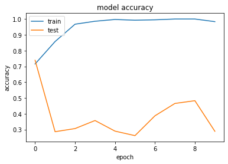

```python
plt.plot(history.history['acc'])
plt.plot(history.history['val_acc'])
plt.title('model accuracy')
plt.ylabel('accuracy')
plt.xlabel('epoch')
plt.legend(['train', 'test'], loc='upper left')
plt.show()
```

# summarize history for loss

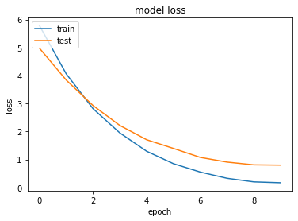

```python
plt.plot(history.history['loss'])
plt.plot(history.history['val_loss'])
plt.title('model loss')
plt.ylabel('loss')
plt.xlabel('epoch')
plt.legend(['train', 'test'], loc='upper left')
plt.show()
```